# Tugas Praktikum 1

Muhammad Rizky Fajar_G1401211009

2023-09-02

## Library / Packages

```r
library("forecast")
```

```r
library("graphics")
library("TTR")
library("TSA")
```

## Impor Data

```r
#install.packages("rio") #install jika belum ada
library(rio)
data <- import("https://raw.githubusercontent.com/mhdrfajar/mpdw/main/data/saham_meta.csv")
```

## Eksplorasi Data

Melihat data menggunakan fungsi `View()`, struktur data menggunakan fungsi `str()`, dan dimensi data menggunakan fungsi `dim()`.

```r
View(data)
data
```

```
##        Tanggal Periode High_Stock
## 1   09-07-2012       1      32.88
## 2   16-07-2012       2      30.50
## 3   23-07-2012       3      29.49
## 4   30-07-2012       4      24.04
## 5   06-08-2012       5      22.45
## 6   13-08-2012       6      22.45
## 7   20-08-2012       7      20.13
## 8   27-08-2012       8      19.53
## 9   03-09-2012       9      19.42
## 10  10-09-2012      10      22.08
## 11  17-09-2012      11      23.37
## 12  24-09-2012      12      21.98
## 13  01-10-2012      13      22.59
## 14  08-10-2012      14      20.75
```

[output cut: 506 more lines]

```r
str(data)
```

```
## 'data.frame':    520 obs. of  3 variables:
##  $ Tanggal   : chr  "09-07-2012" "16-07-2012" "23-07-2012" "30-07-2012" ...
##  $ Periode   : int  1 2 3 4 5 6 7 8 9 10 ...
##  $ High_Stock: num  32.9 30.5 29.5 24 22.5 ...
```

```r
dim(data)
```

```
## [1] 520   3
```

Mengubah data agar terbaca sebagai data deret waktu dengan fungsi `ts()` .

```r
data.ts <- ts(data$High_Stock)
```

Menampilkan ringkasan data

```r
summary(data.ts)
```

```
##    Min. 1st Qu.  Median    Mean 3rd Qu.    Max.
##   19.42   79.58  151.50  154.31  201.21  384.33
```

Membuat plot data deret waktu

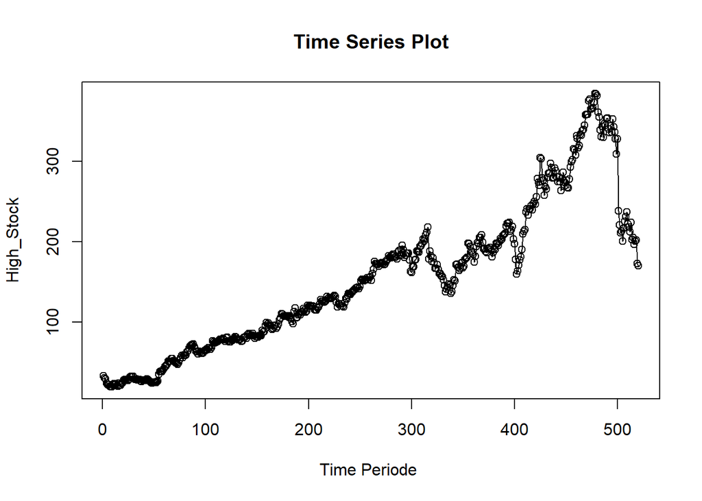

```r
ts.plot(data.ts, xlab="Time Periode ", ylab="High_Stock",
        main = "Time Series Plot")
points(data.ts)
```

Menyimpan plot

```r
#menyimpan plot
dev.copy(png, "eksplorasi.png")
```

```r
dev.off()
```

## Single Moving Average & Double Moving Average

### Pembagian Data

Pembagian data latih dan data uji dilakukan dengan perbandingan 80% data latih dan 20% data uji.

```r
#membagi data latih dan data uji
training_ma <- data[1:416,]
testing_ma <- data[417:520,]
train_ma.ts <- ts(training_ma$High_Stock)
test_ma.ts <- ts(testing_ma$High_Stock)
```

### Eksplorasi Data

Eksplorasi data dilakukan pada keseluruhan data, data latih serta data uji menggunakan plot data deret waktu.

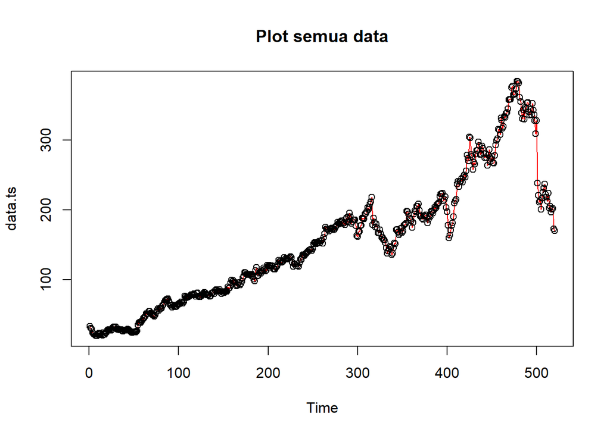

```r
#eksplorasi keseluruhan data
plot(data.ts, col="red",main="Plot semua data")
points(data.ts)
```

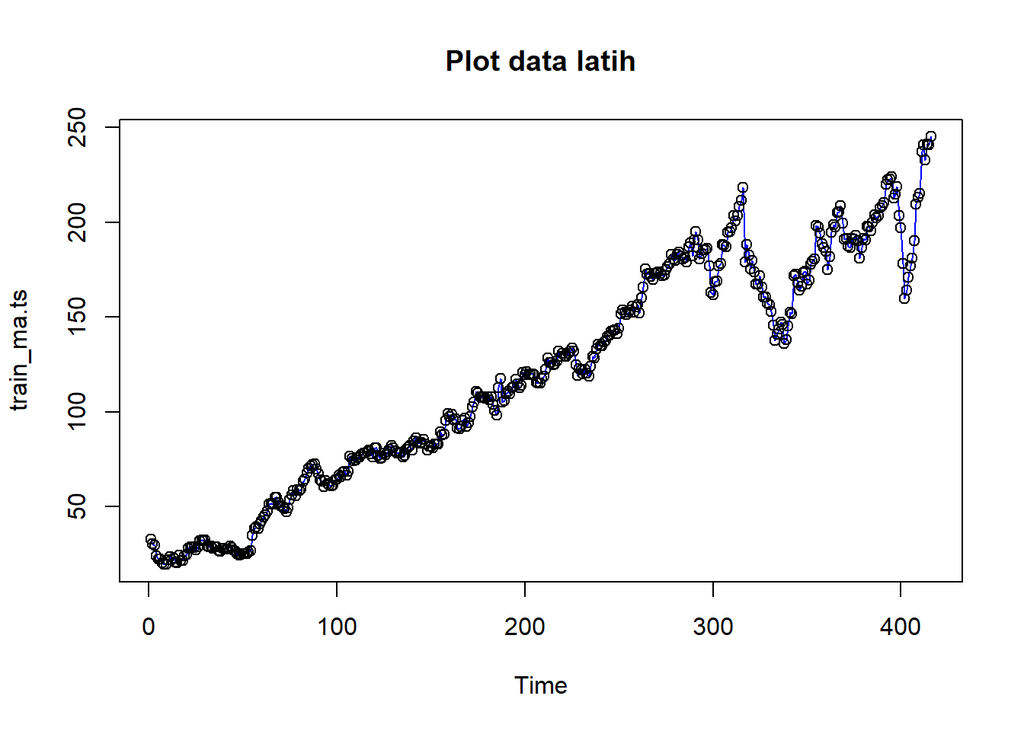

```r
#eksplorasi data latih
plot(train_ma.ts, col="blue",main="Plot data latih")
points(train_ma.ts)
```

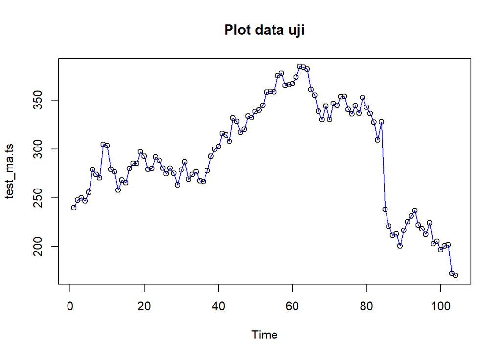

```r
#eksplorasi data uji
plot(test_ma.ts, col="blue",main="Plot data uji")
points(test_ma.ts)
```

Eksplorasi data juga dapat dilakukan menggunakan package `ggplot2` dengan terlebih dahulu memanggil library *package* `ggplot2`.

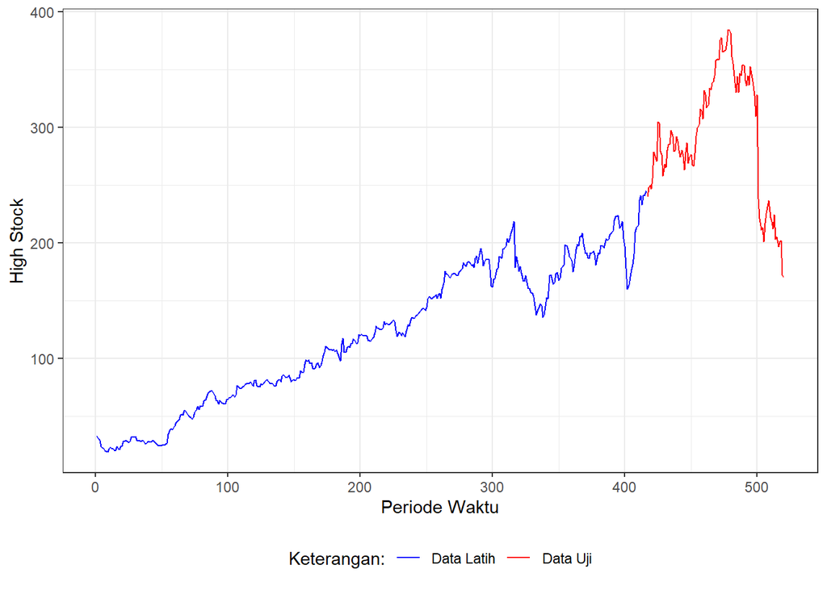

```r
#Eksplorasi dengan GGPLOT
library(ggplot2)
ggplot() +
  geom_line(data = training_ma, aes(x = Periode, y = High_Stock, col = "Data Latih")) +
  geom_line(data = testing_ma, aes(x = Periode, y = High_Stock, col = "Data Uji")) +
  labs(x = "Periode Waktu", y = "High Stock", color = "Legend") +
  scale_colour_manual(name="Keterangan:", breaks = c("Data Latih", "Data Uji"),
                      values = c("blue", "red")) +
  theme_bw() + theme(legend.position = "bottom",
                     plot.caption = element_text(hjust=0.5, size=12))
```

### Single Moving Average (SMA)

Ide dasar dari Single Moving Average (SMA) adalah data suatu periode dipengaruhi oleh data periode sebelumnya. Metode pemulusan ini cocok digunakan untuk pola data stasioner atau konstan. Prinsip dasar metode pemulusan ini adalah data pemulusan pada periode ke-t merupakan rata rata dari m buah data pada periode ke-t hingga periode ke (t-m+1). Data pemulusan pada periode ke-t selanjutnya digunakan sebagai nilai peramalan pada periode ke t+1

Pemulusan menggunakan metode SMA dilakukan dengan fungsi `SMA()`. Dalam hal ini akan dilakukan pemulusan dengan parameter `m=5`.

```r
data.sma<-SMA(train_ma.ts, n=5)
data.sma
```

```
## Time Series:
## Start = 1
## End = 416
## Frequency = 1
##   [1]      NA      NA      NA      NA  27.872  25.786  23.712  21.720  20.796
##  [10]  20.722  20.906  21.276  21.888  22.154  21.834  22.010  21.952  21.730
##  [19]  22.366  23.206  23.956  25.394  26.848  27.706  28.206  28.392  29.008
##  [28]  29.700  30.442  31.508  31.580  30.938  30.312  29.550  28.784  28.654
##  [37]  28.284  27.724  27.660  27.544  27.312  27.456  28.014  28.146  27.992
##  [46]  27.734  27.200  26.250  25.478  25.050  24.808  24.830  25.166  25.602
##  [55]  27.540  30.242  33.094  35.594  38.364  39.840  41.064  42.324  44.144
##  [64]  46.274  48.142  49.478  51.320  52.762  52.924  52.694  52.350  51.152
##  [73]  49.632  49.092  49.702  50.966  52.914  54.602  56.516  57.530  58.214
##  [82]  59.172  60.956  62.680  64.988  67.414  69.134  70.738  71.142  70.592
##  [91]  69.086  67.328  64.926  63.736  62.720  62.208  61.750  61.930  62.060
```

[output cut: 36 more lines]

Data pemulusan pada Periode ke-t selanjutnya digunakan sebagai nilai peramalan pada Periode ke t+1 sehingga hasil peramalan 1 periode kedepan adalah sebagai berikut.

```r
data.ramal<-c(NA,data.sma)
data.ramal #forecast 1 periode ke depan
```

```
##   [1]      NA      NA      NA      NA      NA  27.872  25.786  23.712  21.720
##  [10]  20.796  20.722  20.906  21.276  21.888  22.154  21.834  22.010  21.952
##  [19]  21.730  22.366  23.206  23.956  25.394  26.848  27.706  28.206  28.392
##  [28]  29.008  29.700  30.442  31.508  31.580  30.938  30.312  29.550  28.784
##  [37]  28.654  28.284  27.724  27.660  27.544  27.312  27.456  28.014  28.146
##  [46]  27.992  27.734  27.200  26.250  25.478  25.050  24.808  24.830  25.166
##  [55]  25.602  27.540  30.242  33.094  35.594  38.364  39.840  41.064  42.324
##  [64]  44.144  46.274  48.142  49.478  51.320  52.762  52.924  52.694  52.350
##  [73]  51.152  49.632  49.092  49.702  50.966  52.914  54.602  56.516  57.530
##  [82]  58.214  59.172  60.956  62.680  64.988  67.414  69.134  70.738  71.142
##  [91]  70.592  69.086  67.328  64.926  63.736  62.720  62.208  61.750  61.930
## [100]  62.060  62.476  63.500  64.472  65.776  66.604  67.050  67.448  69.646
## [109]  71.146  72.258  73.870  75.294  75.144  75.540  76.412  77.142  77.814
## [118]  78.558  78.652  78.180  78.684  79.128  78.546  78.052  77.984  77.474
## [127]  76.704  77.120  78.024  79.326  79.864  80.252  80.092  79.730  78.990
```

[output cut: 32 more lines]

Selanjutnya akan dilakukan peramalan sejumlah data uji yaitu 104 periode. Pada metode SMA, hasil peramalan 104 Periode ke depan akan bernilai sama dengan hasil peramalan 1 Periode kedepan. Dalam hal ini akan dilakukan penggabungan data aktual train, data hasil pemulusan dan data hasil ramalan 104 periode kedepan.

```r
data.gab<-cbind(aktual=c(train_ma.ts,rep(NA,104)),pemulusan=c(data.sma,rep(NA,104)),ramalan=c(data.ramal,rep(data.ramal[length(data.ramal)],103)))
data.gab #forecast 104 Periode ke depan
```

```
##        aktual pemulusan ramalan
##   [1,]  32.88        NA      NA
##   [2,]  30.50        NA      NA
##   [3,]  29.49        NA      NA
##   [4,]  24.04        NA      NA
##   [5,]  22.45    27.872      NA
##   [6,]  22.45    25.786  27.872
##   [7,]  20.13    23.712  25.786
##   [8,]  19.53    21.720  23.712
##   [9,]  19.42    20.796  21.720
##  [10,]  22.08    20.722  20.796
##  [11,]  23.37    20.906  20.722
##  [12,]  21.98    21.276  20.906
##  [13,]  22.59    21.888  21.276
##  [14,]  20.75    22.154  21.888
```

[output cut: 506 more lines]

Adapun plot data deret waktu dari hasil peramalan yang dilakukan adalah sebagai berikut.

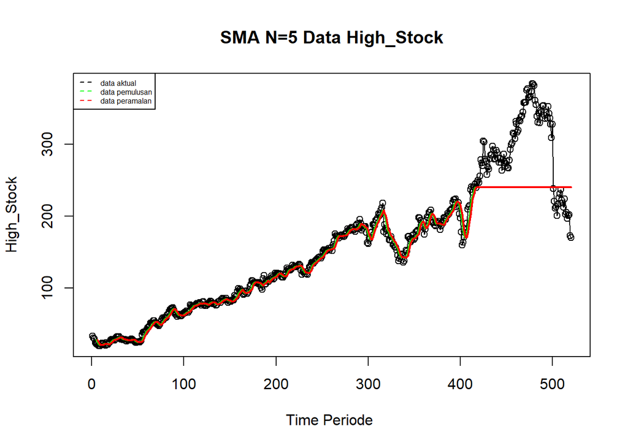

```r
ts.plot(data.ts, xlab="Time Periode ", ylab="High_Stock", main= "SMA N=5 Data High_Stock")
points(data.ts)
lines(data.gab[,2],col="green",lwd=2)
lines(data.gab[,3],col="red",lwd=2)
legend("topleft",c("data aktual","data pemulusan","data peramalan"), lty=8, col=c("black","green","red"), cex=0.5)
```

Selanjutnya perhitungan akurasi dilakukan dengan ukuran akurasi *Sum Squares Error* (SSE), *Mean Square Error* (MSE) dan *Mean Absolute Percentage Error* (MAPE). Perhitungan akurasi dilakukan baik pada data latih maupun pada data uji.

```r
#Menghitung nilai keakuratan data latih
error_train.sma = train_ma.ts-data.ramal[1:length(train_ma.ts)]
SSE_train.sma = sum(error_train.sma[6:length(train_ma.ts)]^2)
MSE_train.sma = mean(error_train.sma[6:length(train_ma.ts)]^2)
MAPE_train.sma = mean(abs((error_train.sma[6:length(train_ma.ts)]/train_ma.ts[6:length(train_ma.ts)])*100))

akurasi_train.sma <- matrix(c(SSE_train.sma, MSE_train.sma, MAPE_train.sma))
row.names(akurasi_train.sma)<- c("SSE", "MSE", "MAPE")
colnames(akurasi_train.sma) <- c("Akurasi m = 5")
akurasi_train.sma
```

```
##      Akurasi m = 5
## SSE   25451.880559
## MSE      61.926717
## MAPE      4.813099
```

Dalam hal ini nilai MAPE data latih pada metode pemulusan SMA kurang dari 10%, nilai ini dapat dikategorikan sebagai nilai akurasi yang sangat baik. Selanjutnya dilakukan perhitungan nilai MAPE data uji pada metde pemulusan SMA.

```r
#Menghitung nilai keakuratan data uji
error_test.sma = test_ma.ts-data.gab[417:520,3]
SSE_test.sma = sum(error_test.sma^2)
MSE_test.sma = mean(error_test.sma^2)
MAPE_test.sma = mean(abs((error_test.sma/test_ma.ts*100)))

akurasi_test.sma <- matrix(c(SSE_test.sma, MSE_test.sma, MAPE_test.sma))
row.names(akurasi_test.sma)<- c("SSE", "MSE", "MAPE")
colnames(akurasi_test.sma) <- c("Akurasi m = 5")
akurasi_test.sma
```

```
##      Akurasi m = 5
## SSE    588174.8505
## MSE      5655.5274
## MAPE       20.5381
```

Perhitungan akurasi menggunakan data latih menghasilkan nilai MAPE yang kurang dari 50% sehingga nilai akurasi ini dapat dikategorikan sebagai cukup baik atau dapat dikatakan hasil peramalan layak.

### Double Moving Average (DMA)

Metode pemulusan Double Moving Average (DMA) pada dasarnya mirip dengan SMA. Namun demikian, metode ini lebih cocok digunakan untuk pola data trend. Proses pemulusan dengan rata rata dalam metode ini dilakukan sebanyak 2 kali.

```r
m <- 5
data.sma<-SMA(train_ma.ts, n=m)
dma <- SMA(data.sma, n = m)
At <- 2*data.sma - dma
Bt <- 2/(m-1)*(data.sma - dma)
data.dma<- At+Bt
data.ramal2<- c(NA, data.dma)

t = 1:104
f = c()

for (i in t) {
  f[i] = At[length(At)] + Bt[length(Bt)]*(i)
}

data.gab2 <- cbind(aktual = c(train_ma.ts,rep(NA,104)), pemulusan1 = c(data.sma,rep(NA,104)),pemulusan2 = c(data.dma, rep(NA,104)),At = c(At, rep(NA,104)), Bt = c(Bt,rep(NA,104)),ramalan = c(data.ramal2, f[-1]))
data.gab2
```

```
##        aktual pemulusan1 pemulusan2       At          Bt   ramalan
##   [1,]  32.88         NA         NA       NA          NA        NA
##   [2,]  30.50         NA         NA       NA          NA        NA
##   [3,]  29.49         NA         NA       NA          NA        NA
##   [4,]  24.04         NA         NA       NA          NA        NA
##   [5,]  22.45     27.872         NA       NA          NA        NA
##   [6,]  22.45     25.786         NA       NA          NA        NA
##   [7,]  20.13     23.712         NA       NA          NA        NA
##   [8,]  19.53     21.720         NA       NA          NA        NA
##   [9,]  19.42     20.796   16.02420  17.6148 -1.59060006        NA
##  [10,]  22.08     20.722   17.98420  18.8968 -0.91260012  16.02420
##  [11,]  23.37     20.906   19.90820  20.2408 -0.33260008  17.98420
##  [12,]  21.98     21.276   21.56400  21.4680  0.09600002  19.90820
##  [13,]  22.59     21.888   23.04360  22.6584  0.38519996  21.56400
##  [14,]  20.75     22.154   23.30120  22.9188  0.38239998  23.04360
```

[output cut: 506 more lines]

Hasil pemulusan menggunakan metode DMA divisualisasikan sebagai berikut

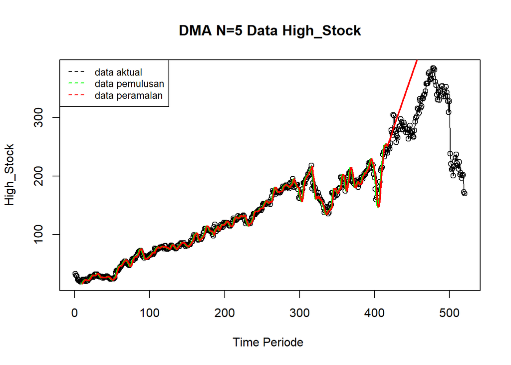

```r
ts.plot(data.ts, xlab="Time Periode ", ylab="High_Stock", main= "DMA N=5 Data High_Stock")
points(data.ts)
lines(data.gab2[,3],col="green",lwd=2)
lines(data.gab2[,6],col="red",lwd=2)
legend("topleft",c("data aktual","data pemulusan","data peramalan"), lty=8, col=c("black","green","red"), cex=0.8)
```

Selanjutnya perhitungan akurasi dilakukan baik pada data latih maupun data uji. Perhitungan akurasi dilakukan dengan ukuran akurasi SSE, MSE dan MAPE.

```r
#Menghitung nilai keakuratan data latih
error_train.dma = train_ma.ts-data.ramal2[1:length(train_ma.ts)]
SSE_train.dma = sum(error_train.dma[10:length(train_ma.ts)]^2)
MSE_train.dma = mean(error_train.dma[10:length(train_ma.ts)]^2)
MAPE_train.dma = mean(abs((error_train.dma[10:length(train_ma.ts)]/train_ma.ts[10:length(train_ma.ts)])*100))

akurasi_train.dma <- matrix(c(SSE_train.dma, MSE_train.dma, MAPE_train.dma))
row.names(akurasi_train.dma)<- c("SSE", "MSE", "MAPE")
colnames(akurasi_train.dma) <- c("Akurasi m = 5")
akurasi_train.dma
```

```
##      Akurasi m = 5
## SSE   21459.296123
## MSE      52.725543
## MAPE      4.356262
```

Perhitungan akurasi pada data latih menggunakan nilai MAPE menghasilkan nilai MAPE yang kurang dari 10% sehingga dikategorikan sangat baik. Selanjutnya, perhitungan nilai akurasi dilakukan pada data uji.

```r
#Menghitung nilai keakuratan data uji
error_test.dma = test_ma.ts-data.gab2[417:520,6]
SSE_test.dma = sum(error_test.dma^2)
MSE_test.dma = mean(error_test.dma^2)
MAPE_test.dma = mean(abs((error_test.dma/test_ma.ts*100)))

akurasi_test.dma <- matrix(c(SSE_test.dma, MSE_test.dma, MAPE_test.dma))
row.names(akurasi_test.dma)<- c("SSE", "MSE", "MAPE")
colnames(akurasi_test.dma) <- c("Akurasi m = 5")
akurasi_test.dma
```

```
##      Akurasi m = 5
## SSE   4.190127e+06
## MSE   4.028968e+04
## MAPE  6.021676e+01
```

## Single Exponential Smoothing & Double Exponential Smoothing

Metode *Exponential Smoothing* adalah metode pemulusan dengan melakukan pembobotan menurun secara eksponensial. Nilai yang lebih baru diberi bobot yang lebih besar dari nilai terdahulu. Terdapat satu atau lebih parameter pemulusan yang ditentukan secara eksplisit, dan hasil pemilihan parameter tersebut akan menentukan bobot yang akan diberikan pada nilai pengamatan. Ada dua macam model, yaitu model tunggal dan ganda.

### Pembagian Data

Pembagian data latih dan data uji dilakukan dengan perbandingan 80% data latih dan 20% data uji.

```r
#membagi training dan testing
training<-data[1:416,]
testing<-data[417:520,]
train.ts <- ts(training$High_Stock)
test.ts <- ts(testing$High_Stock)
```

### Eksplorasi

Eksplorasi dilakukan dengan membuat plot data deret waktu untuk keseluruhan data, data latih, dan data uji.

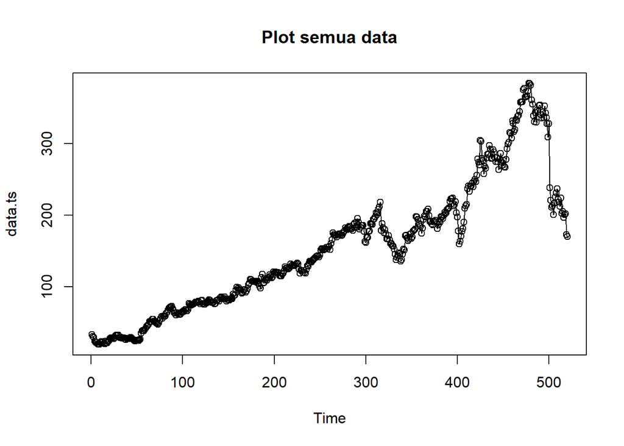

```r
#eksplorasi data
plot(data.ts, col="black",main="Plot semua data")
points(data.ts)
```

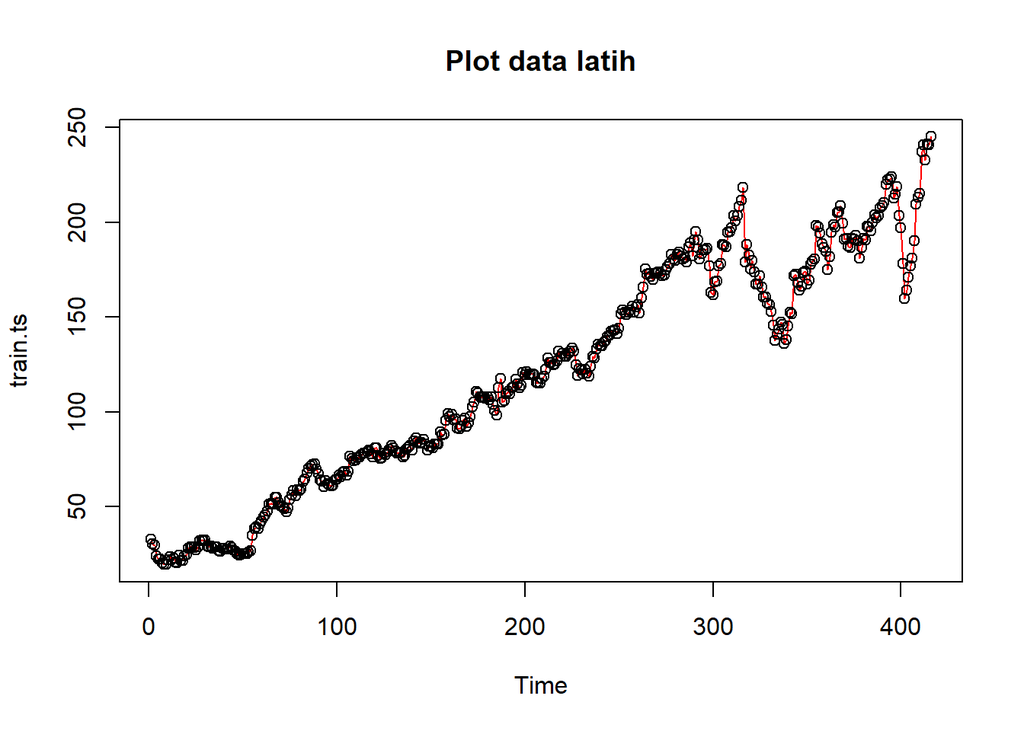

```r
plot(train.ts, col="red",main="Plot data latih")
points(train.ts)
```

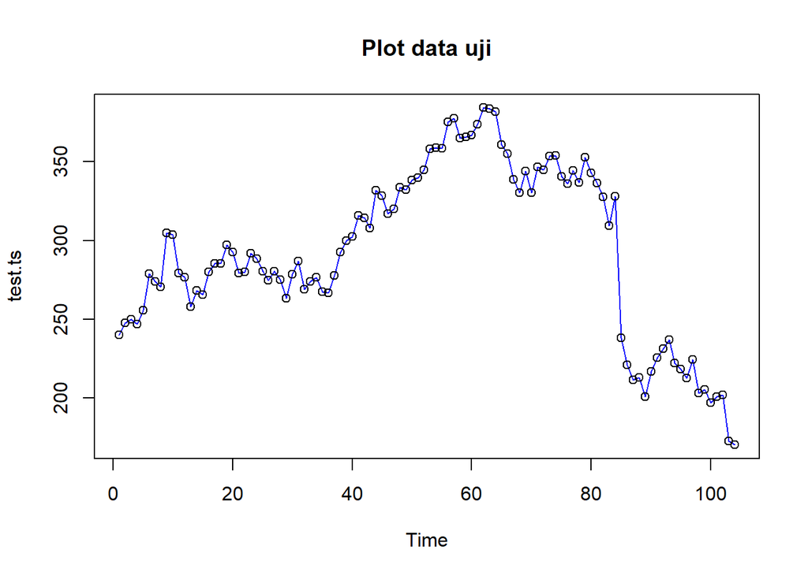

```r
plot(test.ts, col="blue",main="Plot data uji")
points(test.ts)
```

Eksplorasi data juga dapat dilakukan menggunakan package `ggplot2` .

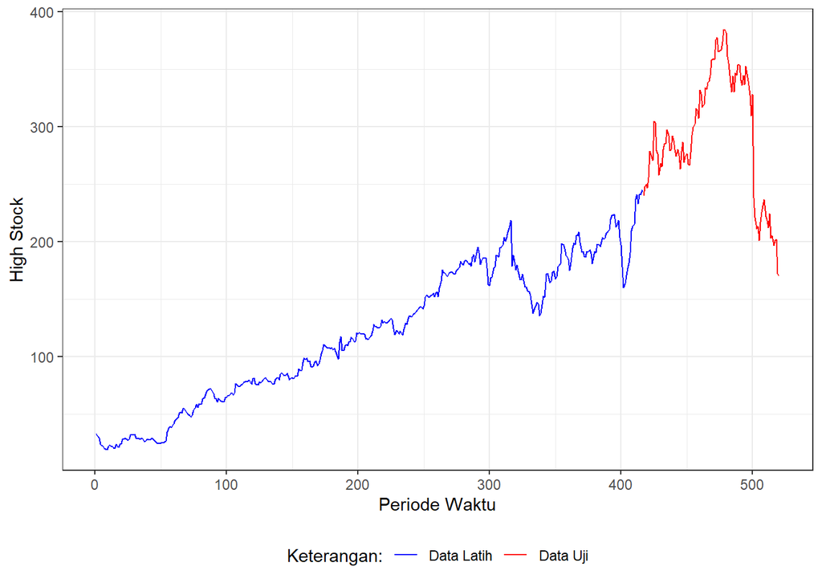

```r
#Eksplorasi dengan GGPLOT
library(ggplot2)
ggplot() +
  geom_line(data = training, aes(x = Periode, y = High_Stock, col = "Data Latih")) +
  geom_line(data = testing, aes(x = Periode, y = High_Stock, col = "Data Uji")) +
  labs(x = "Periode Waktu", y = "High Stock", color = "Legend") +
  scale_colour_manual(name="Keterangan:", breaks = c("Data Latih", "Data Uji"),
                      values = c("blue", "red")) +
  theme_bw() + theme(legend.position = "bottom",
                     plot.caption = element_text(hjust=0.5, size=12))
```

### SES

Single Exponential Smoothing merupakan metode pemulusan yang tepat digunakan untuk data dengan pola stasioner atau konstan.

Nilai pemulusan pada periode ke-t didapat dari persamaan:

$$\tilde{y}_T=\lambda y_t+(1-\lambda)\tilde{y}_{T-1}$$

Nilai parameter $\lambda$ adalah nilai antara 0 dan 1.

Nilai pemulusan periode ke-t bertindak sebagai nilai ramalan pada periode ke-$(T+\tau)$.

$$\tilde{y}_{T+\tau}(T)=\tilde{y}_T$$

Pemulusan dengan metode SES dapat dilakukan dengan dua fungsi dari *packages* berbeda, yaitu (1) fungsi `ses()` dari *packages* `forecast` dan (2) fungsi `HoltWinters` dari *packages* `stats` .

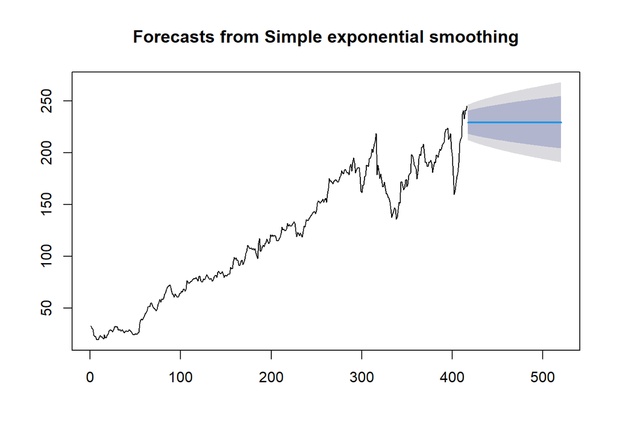

```r
#Cara 1 (fungsi ses)
ses.1 <- ses(train.ts, h = 104, alpha = 0.2)
plot(ses.1)
```

```r
ses.1
```

```
##     Point Forecast    Lo 80    Hi 80    Lo 95    Hi 95
## 417       229.6183 218.4719 240.7646 212.5714 246.6652
## 418       229.6183 218.2512 240.9854 212.2338 247.0028
## 419       229.6183 218.0347 241.2019 211.9026 247.3339
## 420       229.6183 217.8221 241.4145 211.5776 247.6590
## 421       229.6183 217.6133 241.6233 211.2582 247.9783
## 422       229.6183 217.4081 241.8285 210.9444 248.2922
## 423       229.6183 217.2062 242.0303 210.6357 248.6009
## 424       229.6183 217.0076 242.2290 210.3319 248.9046
## 425       229.6183 216.8121 242.4245 210.0329 249.2037
## 426       229.6183 216.6195 242.6171 209.7384 249.4982
## 427       229.6183 216.4297 242.8068 209.4481 249.7884
## 428       229.6183 216.2427 242.9939 209.1620 250.0745
## 429       229.6183 216.0582 243.1784 208.8799 250.3567
## 430       229.6183 215.8761 243.3604 208.6015 250.6351
```

[output cut: 90 more lines]

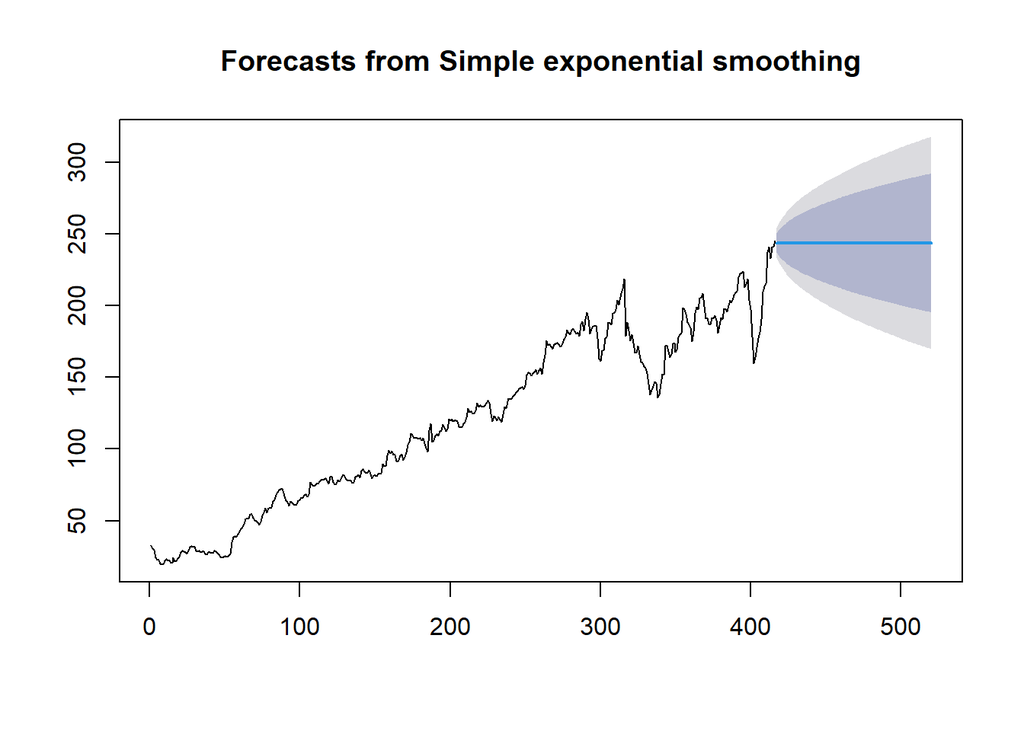

```r
ses.2<- ses(train.ts, h = 104, alpha = 0.7)
plot(ses.2)
```

```r
ses.2
```

```
##     Point Forecast    Lo 80    Hi 80    Lo 95    Hi 95
## 417       243.7324 236.9868 250.4781 233.4159 254.0490
## 418       243.7324 235.4983 251.9665 231.1395 256.3254
## 419       243.7324 234.2405 253.2244 229.2157 258.2491
## 420       243.7324 233.1308 254.3340 227.5187 259.9462
## 421       243.7324 232.1268 255.3380 225.9832 261.4817
## 422       243.7324 231.2030 256.2619 224.5703 262.8946
## 423       243.7324 230.3427 257.1221 223.2546 264.2102
## 424       243.7324 229.5345 257.9303 222.0186 265.4463
## 425       243.7324 228.7699 258.6950 220.8492 266.6156
## 426       243.7324 228.0425 259.4224 219.7367 267.7281
## 427       243.7324 227.3473 260.1175 218.6736 268.7912
## 428       243.7324 226.6805 260.7843 217.6538 269.8111
## 429       243.7324 226.0388 261.4261 216.6724 270.7925
## 430       243.7324 225.4196 262.0453 215.7253 271.7395
```

[output cut: 90 more lines]

Untuk mendapatkan gambar hasil pemulusan pada data latih dengan fungsi `ses()` , perlu digunakan fungsi `autoplot()` dan `autolayer()` dari *library packages* `ggplot2` .

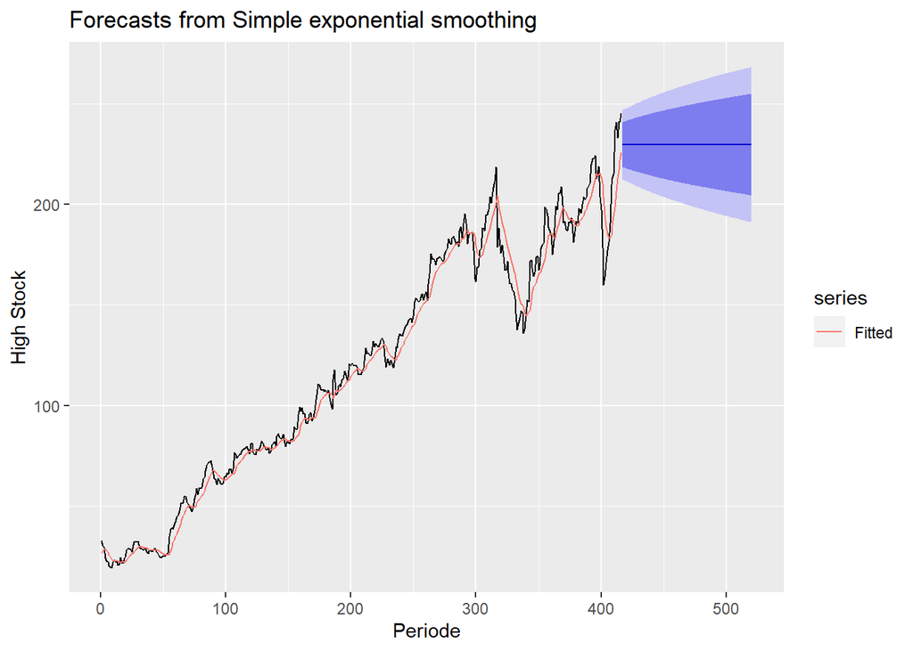

```r
autoplot(ses.1) +
  autolayer(fitted(ses.1), series="Fitted") +
  ylab("High Stock") + xlab("Periode")
```

Pada fungsi `ses()` , terdapat beberapa argumen yang umum digunakan, yaitu nilia `y` , `gamma` , `beta` , `alpha` , dan `h` .

Nilai `y` adalah nilai data deret waktu, `gamma` adalah parameter pemulusan untuk komponen musiman, `beta` adalah parameter pemulusan untuk tren, dan `alpha` adalah parameter pemulusan untuk stasioner, serta `h` adalah banyaknya periode yang akan diramalkan.

Kasus di atas merupakan contoh inisialisasi nilai parameter $\lambda$ dengan nilai `alpha` 0,2 dan 0,7 dan banyak periode data yang akan diramalkan adalah sebanyak 104 periode. Selanjutnya akan digunakan fungsi `HoltWinters()` dengan nilai inisialisasi parameter dan panjang periode peramalan yang sama dengan fungsi `ses()` .

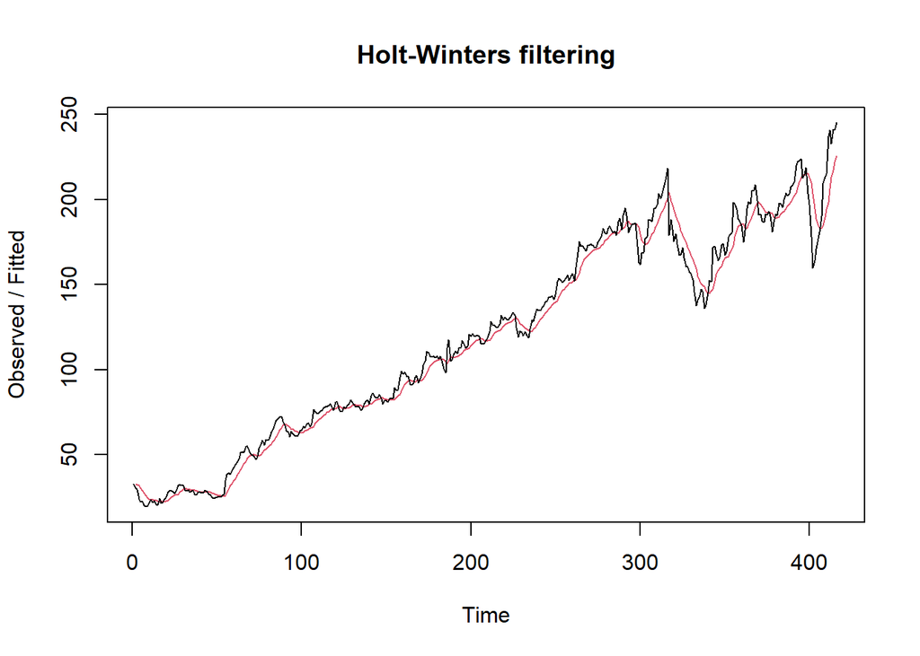

```r
#Cara 2 (fungsi Holtwinter)
ses1<- HoltWinters(train.ts, gamma = FALSE, beta = FALSE, alpha = 0.2)
plot(ses1)
```

```r
#ramalan
ramalan1<- forecast(ses1, h=104)
ramalan1
```

```
##     Point Forecast    Lo 80    Hi 80    Lo 95    Hi 95
## 417       229.6183 218.8746 240.3619 213.1873 246.0493
## 418       229.6183 218.6619 240.5747 212.8619 246.3747
## 419       229.6183 218.4532 240.7834 212.5427 246.6939
## 420       229.6183 218.2483 240.9883 212.2294 247.0072
## 421       229.6183 218.0470 241.1895 211.9216 247.3150
## 422       229.6183 217.8492 241.3874 211.6190 247.6175
## 423       229.6183 217.6547 241.5819 211.3215 247.9151
## 424       229.6183 217.4632 241.7733 211.0288 248.2078
## 425       229.6183 217.2748 241.9618 210.7405 248.4961
## 426       229.6183 217.0892 242.1474 210.4566 248.7799
## 427       229.6183 216.9062 242.3303 210.1769 249.0597
## 428       229.6183 216.7259 242.5107 209.9011 249.3355
## 429       229.6183 216.5481 242.6885 209.6291 249.6074
## 430       229.6183 216.3726 242.8639 209.3608 249.8758
```

[output cut: 90 more lines]

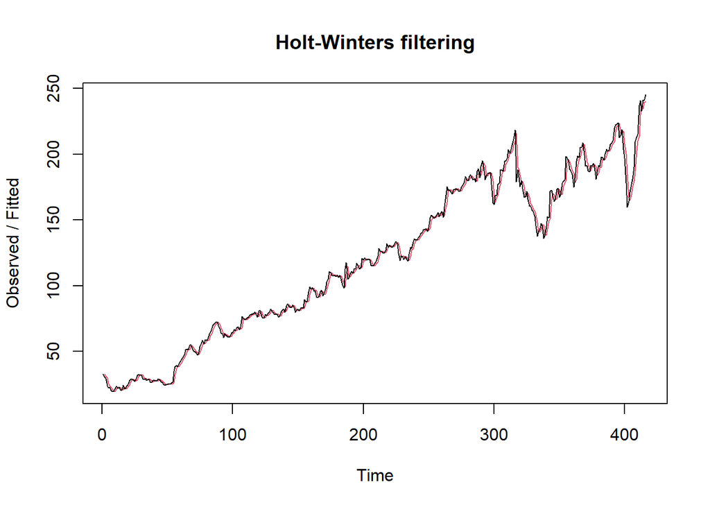

```r
ses2<- HoltWinters(train.ts, gamma = FALSE, beta = FALSE, alpha = 0.7)
plot(ses2)
```

```r
#ramalan
ramalan2<- forecast(ses2, h=104)
ramalan2
```

```
##     Point Forecast    Lo 80    Hi 80    Lo 95    Hi 95
## 417       243.7324 237.0511 250.4138 233.5142 253.9506
## 418       243.7324 235.5768 251.8880 231.2595 256.2054
## 419       243.7324 234.3309 253.1339 229.3541 258.1107
## 420       243.7324 233.2319 254.2330 227.6732 259.7916
## 421       243.7324 232.2374 255.2274 226.1523 261.3125
## 422       243.7324 231.3224 256.1425 224.7529 262.7119
## 423       243.7324 230.4703 256.9945 223.4498 264.0150
## 424       243.7324 229.6698 257.7950 222.2255 265.2393
## 425       243.7324 228.9125 258.5524 221.0673 266.3975
## 426       243.7324 228.1920 259.2728 219.9654 267.4994
## 427       243.7324 227.5035 259.9613 218.9124 268.5524
## 428       243.7324 226.8430 260.6218 217.9023 269.5625
## 429       243.7324 226.2074 261.2574 216.9303 270.5346
## 430       243.7324 225.5941 261.8708 215.9922 271.4726
```

[output cut: 90 more lines]

Fungsi `HoltWinters` memiliki argumen yang sama dengan fungsi `ses()` . Argumen-argumen kedua fungsi dapat dilihat lebih lanjut dengan `?ses()` atau `?HoltWinters` .

Nilai parameter $\alpha$ dari kedua fungsi dapat dioptimalkan menyesuaikan dari *error*-nya paling minimumnya. Caranya adalah dengan membuat parameter $\alpha =$ `NULL` .

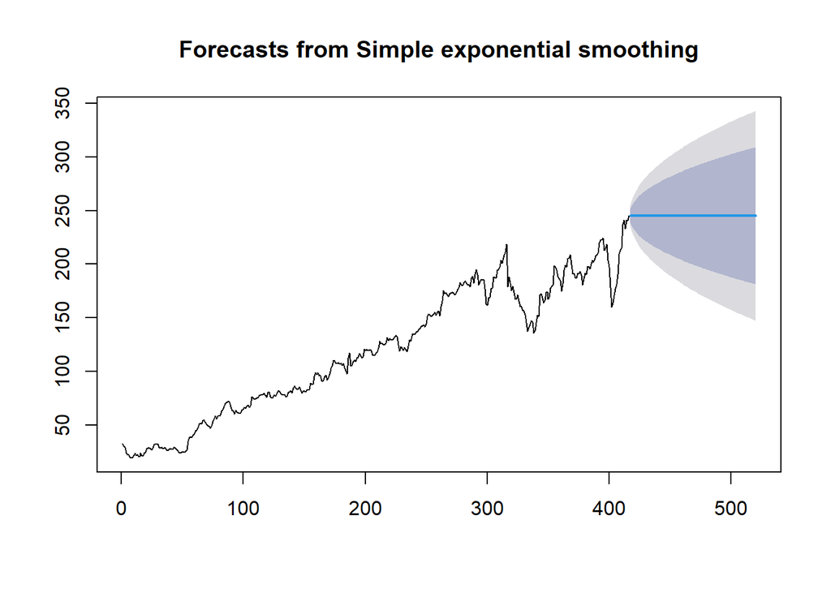

```r
#SES
ses.opt <- ses(train.ts, h = 104, alpha = NULL)
plot(ses.opt)
```

```r
ses.opt
```

```
##     Point Forecast    Lo 80    Hi 80    Lo 95    Hi 95
## 417       245.1896 238.9303 251.4488 235.6169 254.7623
## 418       245.1896 236.3381 254.0410 231.6524 258.7267
## 419       245.1896 234.3490 256.0302 228.6103 261.7688
## 420       245.1896 232.6720 257.7071 226.0456 264.3335
## 421       245.1896 231.1946 259.1845 223.7861 266.5930
## 422       245.1896 229.8589 260.5202 221.7433 268.6358
## 423       245.1896 228.6306 261.7485 219.8648 270.5143
## 424       245.1896 227.4873 262.8918 218.1163 272.2628
## 425       245.1896 226.4135 263.9656 216.4741 273.9051
## 426       245.1896 225.3979 264.9813 214.9208 275.4583
## 427       245.1896 224.4319 265.9472 213.4434 276.9357
## 428       245.1896 223.5089 266.8702 212.0318 278.3473
## 429       245.1896 222.6236 267.7555 210.6779 279.7012
## 430       245.1896 221.7718 268.6073 209.3752 281.0040
```

[output cut: 90 more lines]

```r
#Lamda Optimum Holt Winter
sesopt<- HoltWinters(train.ts, gamma = FALSE, beta = FALSE,alpha = NULL)
sesopt
```

```
## Holt-Winters exponential smoothing without trend and without seasonal component.
##
## Call:
## HoltWinters(x = train.ts, alpha = NULL, beta = FALSE, gamma = FALSE)
##
## Smoothing parameters:
##  alpha: 0.9999236
##  beta : FALSE
##  gamma: FALSE
##
## Coefficients:
##       [,1]
## a 245.1897
```

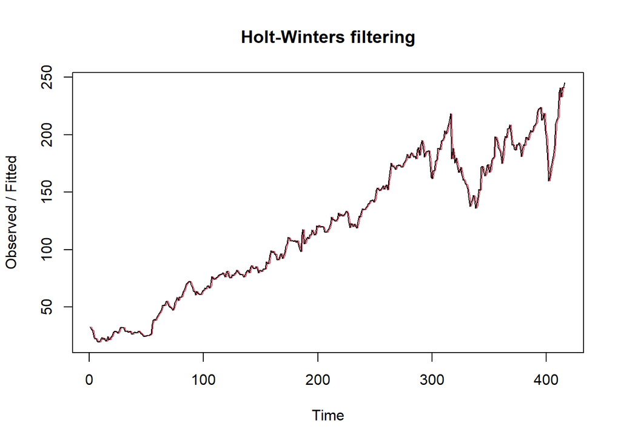

```r
plot(sesopt)
```

```r
#ramalan
ramalanopt<- forecast(sesopt, h=104)
ramalanopt
```

```
##     Point Forecast    Lo 80    Hi 80    Lo 95    Hi 95
## 417       245.1897 238.9650 251.4144 235.6698 254.7095
## 418       245.1897 236.3869 253.9924 231.7270 258.6523
## 419       245.1897 234.4087 255.9706 228.7016 261.6777
## 420       245.1897 232.7410 257.6384 226.1510 264.2283
## 421       245.1897 231.2716 259.1077 223.9039 266.4755
## 422       245.1897 229.9433 260.4361 221.8723 268.5070
## 423       245.1897 228.7217 261.6576 220.0041 270.3752
## 424       245.1897 227.5847 262.7946 218.2652 272.1141
## 425       245.1897 226.5168 263.8625 216.6320 273.7473
## 426       245.1897 225.5068 264.8726 215.0873 275.2921
## 427       245.1897 224.5461 265.8333 213.6180 276.7613
## 428       245.1897 223.6281 266.7512 212.2142 278.1652
## 429       245.1897 222.7477 267.6316 210.8677 279.5116
## 430       245.1897 221.9006 268.4788 209.5721 280.8072
```

[output cut: 90 more lines]

Setelah dilakukan peramalan, akan dilakukan perhitungan keakuratan hasil peramalan. Perhitungan akurasi ini dilakukan baik pada data latih dan data uji.

#### Akurasi Data Latih

Perhitungan akurasi data dapat dilakukan dengan cara langsung maupun manual. Secara langsung, nilai akurasi dapat diambil dari objek yang tersimpan pada hasil SES, yaitu *sum of squared errors* (SSE). Nilai akurasi lain dapat dihitung pula dari nilai SSE tersebut.

```r
#Keakuratan Metode
#Pada data training
SSE1<-ses1$SSE
MSE1<-ses1$SSE/length(train.ts)
RMSE1<-sqrt(MSE1)

akurasi1 <- matrix(c(SSE1,MSE1,RMSE1))
row.names(akurasi1)<- c("SSE", "MSE", "RMSE")
colnames(akurasi1) <- c("Akurasi lamda=0.2")
akurasi1
```

```
##      Akurasi lamda=0.2
## SSE       31427.548544
## MSE          75.546992
## RMSE          8.691777
```

```r
SSE2<-ses2$SSE
MSE2<-ses2$SSE/length(train.ts)
RMSE2<-sqrt(MSE2)

akurasi2 <- matrix(c(SSE2,MSE2,RMSE2))
row.names(akurasi2)<- c("SSE", "MSE", "RMSE")
colnames(akurasi2) <- c("Akurasi lamda=0.7")
akurasi2
```

```
##      Akurasi lamda=0.7
## SSE       11471.293202
## MSE          27.575224
## RMSE          5.251212
```

```r
#Cara Manual
fitted1<-ramalan1$fitted
sisaan1<-ramalan1$residuals
head(sisaan1)
```

```
## Time Series:
## Start = 1
## End = 6
## Frequency = 1
## [1]        NA -2.380001 -2.914001 -7.781200 -7.814960 -6.251968
```

```r
resid1<-training$High_Stock-ramalan1$fitted
head(resid1)
```

```
## Time Series:
## Start = 1
## End = 6
## Frequency = 1
## [1]        NA -2.380001 -2.914001 -7.781200 -7.814960 -6.251968
```

```r
#Cara Manual
SSE.1=sum(sisaan1[2:length(train.ts)]^2)
SSE.1
```

```
## [1] 31427.55
```

```r
MSE.1 = SSE.1/length(train.ts)
MSE.1
```

```
## [1] 75.54699
```

```r
MAPE.1 = sum(abs(sisaan1[2:length(train.ts)]/train.ts[2:length(train.ts)])*
               100)/length(train.ts)
MAPE.1
```

```
## [1] 5.796069
```

```r
akurasi.1 <- matrix(c(SSE.1,MSE.1,MAPE.1))
row.names(akurasi.1)<- c("SSE", "MSE", "MAPE")
colnames(akurasi.1) <- c("Akurasi lamda=0.2")
akurasi.1
```

```
##      Akurasi lamda=0.2
## SSE       31427.548544
## MSE          75.546992
## MAPE          5.796069
```

```r
fitted2<-ramalan2$fitted
sisaan2<-ramalan2$residuals
head(sisaan2)
```

```
## Time Series:
## Start = 1
## End = 6
## Frequency = 1
## [1]        NA -2.380001 -1.724000 -5.967199 -3.380160 -1.014048
```

```r
resid2<-training$High_Stock-ramalan2$fitted
head(resid2)
```

```
## Time Series:
## Start = 1
## End = 6
## Frequency = 1
## [1]        NA -2.380001 -1.724000 -5.967199 -3.380160 -1.014048
```

```r
SSE.2=sum(sisaan2[2:length(train.ts)]^2)
SSE.2
```

```
## [1] 11471.29
```

```r
MSE.2 = SSE.2/length(train.ts)
MSE.2
```

```
## [1] 27.57522
```

```r
MAPE.2 = sum(abs(sisaan2[2:length(train.ts)]/train.ts[2:length(train.ts)])*
               100)/length(train.ts)
MAPE.2
```

```
## [1] 3.163758
```

```r
akurasi.2 <- matrix(c(SSE.2,MSE.2,MAPE.2))
row.names(akurasi.2)<- c("SSE", "MSE", "MAPE")
colnames(akurasi.2) <- c("Akurasi lamda=0.7")
akurasi.2
```

```
##      Akurasi lamda=0.7
## SSE       11471.293202
## MSE          27.575224
## MAPE          3.163758
```

Berdasarkan nilai SSE, MSE, RMSE, dan MAPE di antara kedua parameter, nilai parameter $\lambda=0,7$ menghasilkan akurasi yang lebih baik dibanding $\lambda=0,2$ . Hal ini dilihat dari nilai masing-masing ukuran akurasi yang lebih kecil. Berdasarkan nilai MAPE-nya, hasil ini dapat dikategorikan sebagai peramalan sangat baik.

#### Akurasi Data Uji

Akurasi data uji dapat dihitung dengan cara yang hampir sama dengan perhitungan akurasi data latih.

```r
selisih1 <- ramalan1$mean - testing$High_Stock
SSEtesting1<-sum(selisih1^2)
MSEtesting1<-SSEtesting1/length(testing)

selisih2<-ramalan2$mean-testing$High_Stock
SSEtesting2<-sum(selisih2^2)
MSEtesting2<-SSEtesting2/length(testing)

selisihopt<-ramalanopt$mean-testing$High_Stock
SSEtestingopt<-sum(selisihopt^2)
MSEtestingopt<-SSEtestingopt/length(testing)

akurasitesting1 <- matrix(c(SSEtesting1,SSEtesting2,SSEtestingopt))
row.names(akurasitesting1)<- c("SSE1", "SSE2", "SSEopt")
akurasitesting1
```

```
##            [,1]
## SSE1   716456.6
## SSE2   550917.8
## SSEopt 536186.2
```

```r
akurasitesting2 <- matrix(c(MSEtesting1,MSEtesting2,MSEtestingopt))
row.names(akurasitesting2)<- c("MSE1", "MSE2", "MSEopt")
akurasitesting2
```

```
##            [,1]
## MSE1   238818.9
## MSE2   183639.3
## MSEopt 178728.7
```

Selain dengan cara di atas, perhitungan nilai akurasi dapat menggunakan fungsi `accuracy()` dari *package* `forecast` . Penggunaannya yaitu dengan menuliskan `accuracy(hasil ramalan, kondisi aktual)` . Contohnya adalah sebagai berikut.

```r
#cara lain
accuracy(ramalanopt,testing$High_Stock)
```

```
##                      ME      RMSE       MAE        MPE      MAPE      MASE
## Training set  0.5116287  4.878216  3.069065  0.3958925  2.843624  1.000009
## Test set     47.8731189 71.802764 61.054139 13.1551346 19.730667 19.893585
##                    ACF1
## Training set 0.08068085
## Test set             NA
```

Dalam hal ini nilai MAPE data latih pada metode pemulusan SES kurang dari 10%, nilai ini dapat dikategorikan sebagai nilai akurasi yang sangat baik. Sedangkan pada perhitungan akurasi menggunakan data latih menghasilkan nilai MAPE yang kurang dari 20% sehingga nilai akurasi ini dapat dikategorikan sebagai baik atau dapat dikatakan hasil peramalan baik.

### DES

Metode pemulusan *Double Exponential Smoothing* (DES) digunakan untuk data yang memiliki pola tren. Metode DES adalah metode semacam SES, hanya saja dilakukan dua kali, yaitu pertama untuk tahapan ‘level’ dan kedua untuk tahapan ‘tren’. Pemulusan menggunakan metode ini akan menghasilkan peramalan tidak konstan untuk periode berikutnya.

Pemulusan dengan metode DES kali ini akan menggunakan fungsi `HoltWinters()` . Jika sebelumnya nilai argumen `beta` dibuat `FALSE` , kali ini argumen tersebut akan diinisialisasi bersamaan dengan nilai `alpha` .

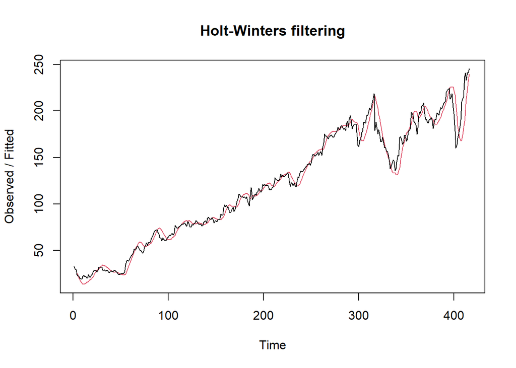

```r
#Lamda=0.2 dan gamma=0.2
des.1<- HoltWinters(train.ts, gamma = FALSE, beta = 0.2, alpha = 0.2)
plot(des.1)
```

```r
#ramalan
ramalandes1<- forecast(des.1, h=104)
ramalandes1
```

```
##     Point Forecast    Lo 80     Hi 80    Lo 95     Hi 95
## 417       246.8919 234.8604  258.9235 228.4913  265.2926
## 418       253.1797 240.8065  265.5529 234.2566  272.1028
## 419       259.4675 246.6439  272.2911 239.8555  279.0795
## 420       265.7552 252.3662  279.1443 245.2784  286.2321
## 421       272.0430 257.9708  286.1153 250.5214  293.5647
## 422       278.3308 263.4583  293.2032 255.5854  301.0762
## 423       284.6186 268.8320  300.4051 260.4751  308.7620
## 424       290.9063 274.0966  307.7160 265.1981  316.6146
## 425       297.1941 279.2578  315.1303 269.7630  324.6252
## 426       303.4819 284.3219  322.6418 274.1792  332.7845
## 427       309.7696 289.2948  330.2444 278.4561  341.0831
## 428       316.0574 294.1825  337.9323 282.6027  349.5121
## 429       322.3452 298.9904  345.6999 286.6271  358.0632
## 430       328.6329 303.7233  353.5425 290.5370  366.7289
```

[output cut: 90 more lines]

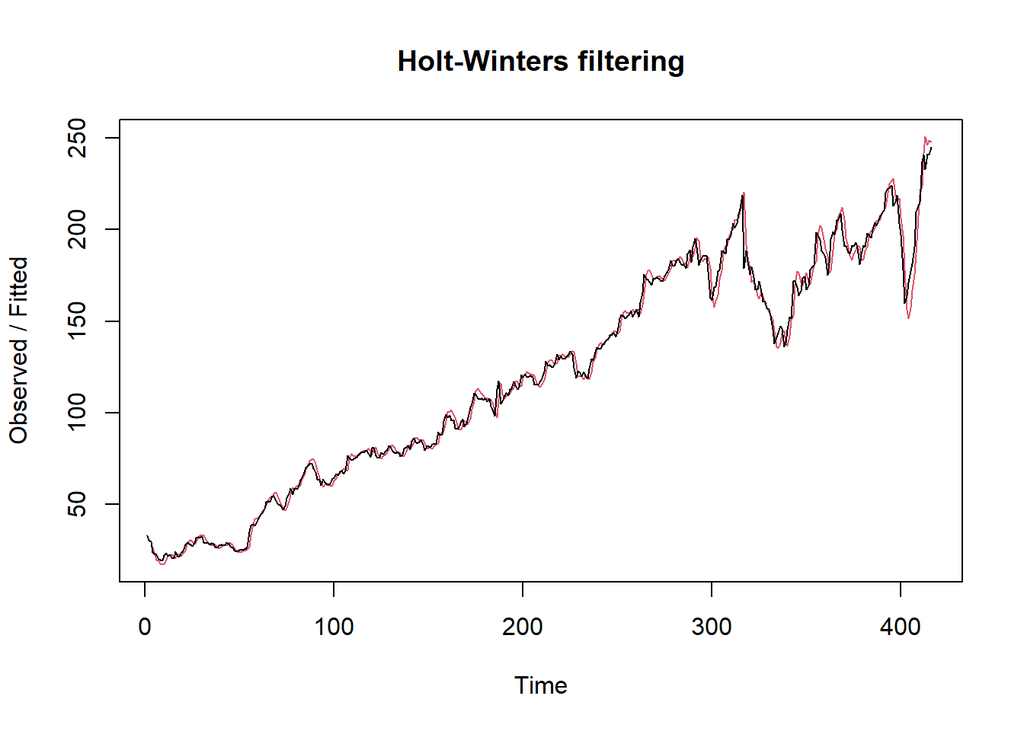

```r
#Lamda=0.6 dan gamma=0.3
des.2<- HoltWinters(train.ts, gamma = FALSE, beta = 0.3, alpha = 0.6)
plot(des.2)
```

```r
#ramalan
ramalandes2<- forecast(des.2, h=104)
ramalandes2
```

```
##     Point Forecast       Lo 80     Hi 80        Lo 95     Hi 95
## 417       249.7836  242.612937  256.9542  238.8170216  260.7502
## 418       253.2705  244.176501  262.3645  239.3624178  267.1786
## 419       256.7574  245.351823  268.1631  239.3140493  274.2008
## 420       260.2444  246.211860  274.2769  238.7834943  281.7053
## 421       263.7313  246.804912  280.6577  237.8446207  289.6180
## 422       267.2182  247.163459  287.2730  236.5471027  297.8894
## 423       270.7052  247.310354  294.1000  234.9258916  306.4844
## 424       274.1921  247.262482  301.1217  233.0068088  315.3774
## 425       277.6790  247.032873  308.3252  230.8097839  324.5483
## 426       281.1659  246.631960  315.6999  228.3507725  333.9811
## 427       284.6529  246.068349  323.2374  225.6429345  343.6628
## 428       288.1398  245.349308  330.9303  222.6973882  353.5822
## 429       291.6267  244.481099  338.7724  219.5237101  363.7298
## 430       295.1137  243.469203  346.7581  216.1302798  374.0970
```

[output cut: 90 more lines]

Selanjutnya jika ingin membandingkan plot data latih dan data uji adalah sebagai berikut.

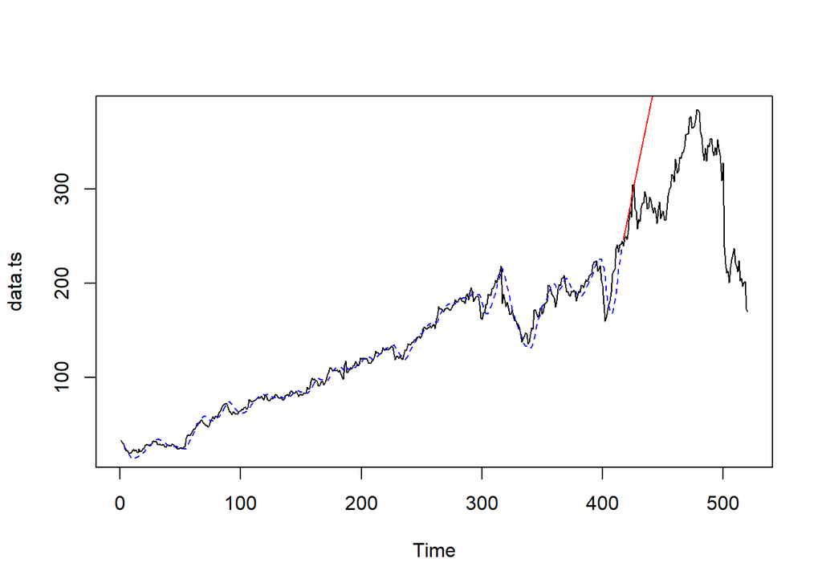

```r
#Visually evaluate the prediction
plot(data.ts)
lines(des.1$fitted[,1], lty=2, col="blue")
lines(ramalandes1$mean, col="red")
```

Untuk mendapatkan nilai parameter optimum dari DES, argumen `alpha` dan `beta` dapat dibuat `NULL` seperti berikut.

```r
#Lamda dan gamma optimum
des.opt<- HoltWinters(train.ts, gamma = FALSE)
des.opt
```

```
## Holt-Winters exponential smoothing with trend and without seasonal component.
##
## Call:
## HoltWinters(x = train.ts, gamma = FALSE)
##
## Smoothing parameters:
##  alpha: 1
##  beta : 0.02671984
##  gamma: FALSE
##
## Coefficients:
##         [,1]
## a 245.190002
## b   1.293898
```

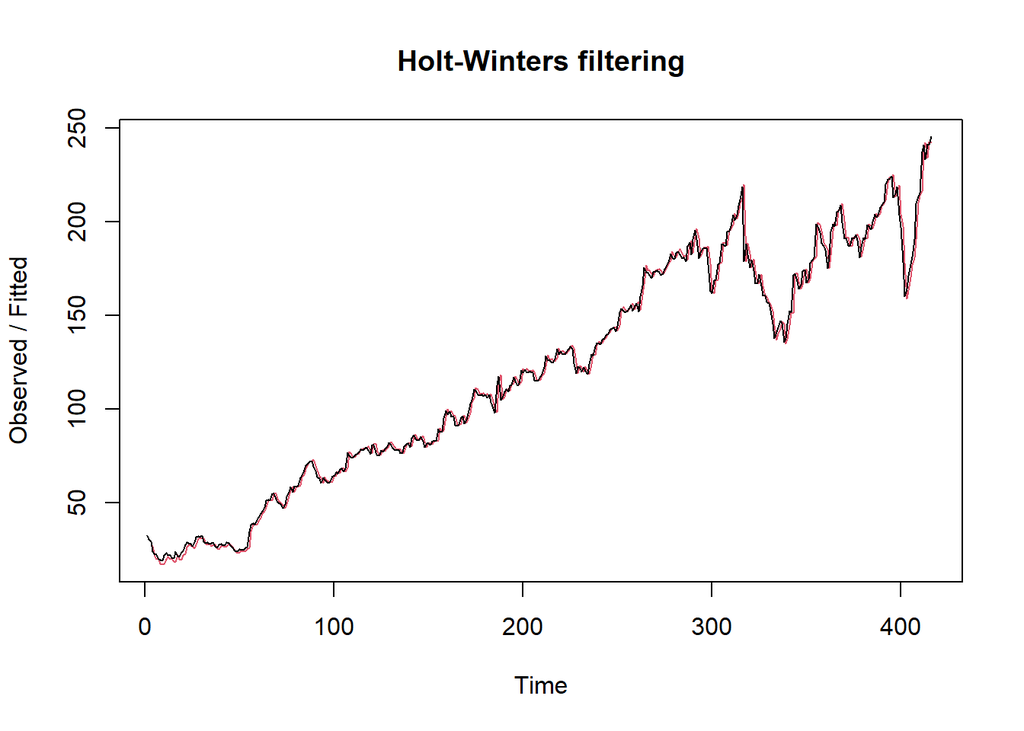

```r
plot(des.opt)
```

```r
#ramalan
ramalandesopt<- forecast(des.opt, h=104)
ramalandesopt
```

```
##     Point Forecast    Lo 80    Hi 80    Lo 95    Hi 95
## 417       246.4839 240.1725 252.7953 236.8314 256.1364
## 418       247.7778 238.7321 256.8235 233.9435 261.6121
## 419       249.0717 237.8454 260.2980 231.9025 266.2409
## 420       250.3656 237.2314 263.4998 230.2786 270.4526
## 421       251.6595 236.7830 266.5360 228.9078 274.4112
## 422       252.9534 236.4458 269.4610 227.7072 278.1995
## 423       254.2473 236.1882 272.3064 226.6283 281.8663
## 424       255.5412 235.9897 275.0926 225.6398 285.4425
## 425       256.8351 235.8364 277.8337 224.7204 288.9497
## 426       258.1290 235.7183 280.5397 223.8548 292.4032
## 427       259.4229 235.6278 283.2179 223.0315 295.8143
## 428       260.7168 235.5594 285.8742 222.2418 299.1917
## 429       262.0107 235.5084 288.5129 221.4790 302.5424
## 430       263.3046 235.4714 291.1377 220.7375 305.8717
```

[output cut: 90 more lines]

Selanjutnya akan dilakukan perhitungan akurasi pada data latih maupun data uji dengan ukuran akurasi SSE, MSE dan MAPE.